# Analyse Bivariée : Prix vs Marché des Produits de Thé (Catégorie Tea) - Marché Nord-Américain

KOUASSI KONAN LEGER

2025-09-01

# Analyse du Tea sur le marché nord-américain

## 1. Chargement des Données et Packages

```r
# Chargement des packages nécessaires
library(readxl)
library(tidyverse)
library(dplyr)
library(lubridate)
library(wordcloud)
library(tidytext)
library(scales)
library(car) # Pour les tests statistiques
library(rstatix) # Pour les tests statistiques
library(ggpubr) # Pour les visualisations statistiques

# Nettoyage de l'environnement
rm(list = ls())

# Importation des données
gnpd <- read_excel("GNPD_tea.xlsx")

# Préparation des données
gnpd <- gnpd %>%
  mutate(
    `Price per 100 g/ml in Euros` = as.numeric(`Price per 100 g/ml in Euros`),
    `Price in US Dollars` = as.numeric(`Price in US Dollars`),
    `Price in Euros` = as.numeric(`Price in Euros`),
    `Unit Pack Size (ml/g)` = as.numeric(`Unit Pack Size (ml/g)`),
    `Alcohol By Volume (%)` = as.numeric(`Alcohol By Volume (%)`),
    `Bar Code` = as.character(`Bar Code`),
    `Date Published` = as.Date(`Date Published`)
  )

# Filtrage pour ne garder que la catégorie Tea et le marché nord-américain
gnpd_tea <- gnpd %>%
  filter(`Sub-Category` == "Tea", Market %in% c("USA", "Canada")) %>%
  filter(!is.na(`Price per 100 g/ml in Euros`))

# Filtrage des valeurs aberrantes
gnpd_north_american_market_tea <- gnpd_tea %>%
  filter(`Unit Pack Size (ml/g)` >= 2.00,
         `Unit Pack Size (ml/g)` <= 5000.00,
         `Price per 100 g/ml in Euros` != 0.00,
         `Price per 100 g/ml in Euros`< 400.00)

# Calcul de la proportion conservée
total_lignes <- nrow(gnpd_tea)
proportion_conservee <- nrow(gnpd_north_american_market_tea) / total_lignes
cat("Proportion des données conservées :", round(proportion_conservee * 100, 2), "%\n")
```

```
## Proportion des données conservées : 96.97 %
```

## 2. Analyse du thé du marché nord-américain

### 2.1 Résumé Statistique des Variables

```r
# Résumé statistique du prix
summary_prix <- summary(gnpd_north_american_market_tea$`Price per 100 g/ml in Euros`)
print("Résumé statistique du prix :")
```

```
## [1] "Résumé statistique du prix :"
```

```r
print(summary_prix)
```

```
##    Min. 1st Qu.  Median    Mean 3rd Qu.    Max.
##   0.070   4.088   8.200  10.796  13.910 163.500
```

```r
# Test de normalité de Shapiro-Wilk
shapiro_test <- shapiro.test(gnpd_north_american_market_tea$`Price per 100 g/ml in Euros`)
print("Test de normalité de Shapiro-Wilk :")
```

```
## [1] "Test de normalité de Shapiro-Wilk :"
```

```r
print(shapiro_test)
```

```
##
##  Shapiro-Wilk normality test
##
## data:  gnpd_north_american_market_tea$`Price per 100 g/ml in Euros`
## W = 0.68893, p-value < 2.2e-16
```

### 2.2 Analyse des Bornes de Tukey

```r
# Calcul des bornes de Tukey
prix <- gnpd_north_american_market_tea$`Price per 100 g/ml in Euros`
prix <- na.omit(prix)
Q1 <- quantile(prix, 0.25)
Q3 <- quantile(prix, 0.75)
IQR <- Q3 - Q1
borne_inf <- Q1 - 1.5 * IQR
borne_sup <- Q3 + 1.5 * IQR

# Affichage des bornes pour info
cat("Limites de Tukey : [", round(borne_inf, 2), ";", round(borne_sup, 2), "]\n")
```

```
## Limites de Tukey : [ -10.65 ; 28.64 ]
```

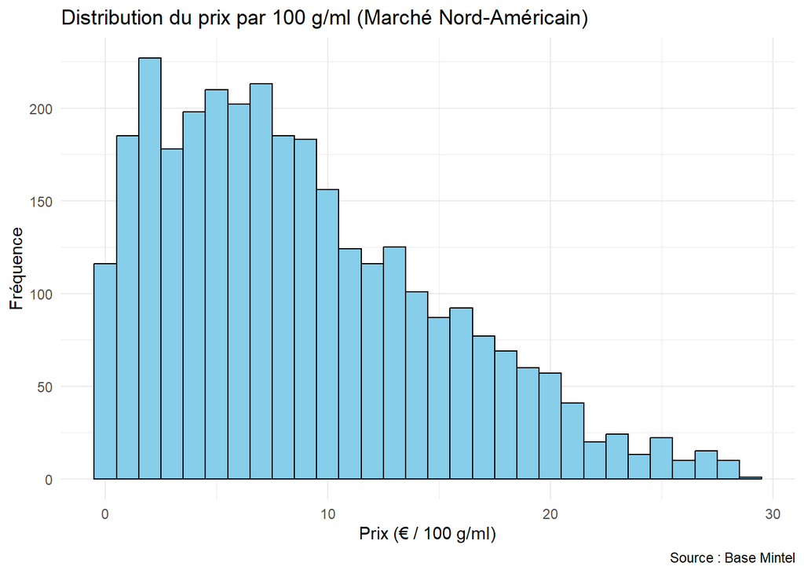

```r
library(ggplot2)

ggplot(gnpd_north_american_market_tea %>%
         filter(!is.na(`Price per 100 g/ml in Euros`),
                `Price per 100 g/ml in Euros`<=borne_sup),
       aes(x = `Price per 100 g/ml in Euros`)) +
  geom_histogram(binwidth = 1, fill = "skyblue", color = "black") +
  labs(title = "Distribution du prix par 100 g/ml (Marché Nord-Américain)",
       x = "Prix (€ / 100 g/ml)", y = "Fréquence",
       caption = "Source : Base Mintel") +
  theme_minimal()
```

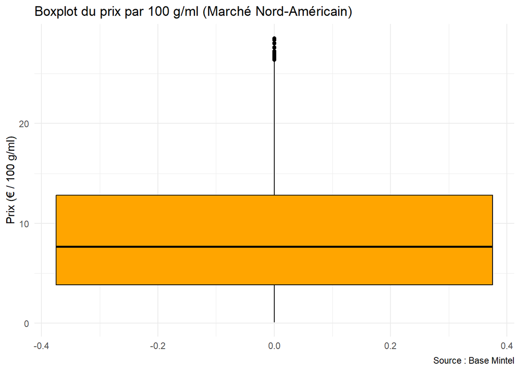

```r
ggplot(gnpd_north_american_market_tea%>%
         filter(!is.na(`Price per 100 g/ml in Euros`),
                `Price per 100 g/ml in Euros`<=borne_sup), aes(y = `Price per 100 g/ml in Euros`)) +
  geom_boxplot(fill = "orange", color = "black") +
  labs(title = "Boxplot du prix par 100 g/ml (Marché Nord-Américain)",
       y = "Prix (€ / 100 g/ml)",
       caption = "Source : Base Mintel") +
  theme_minimal()
```

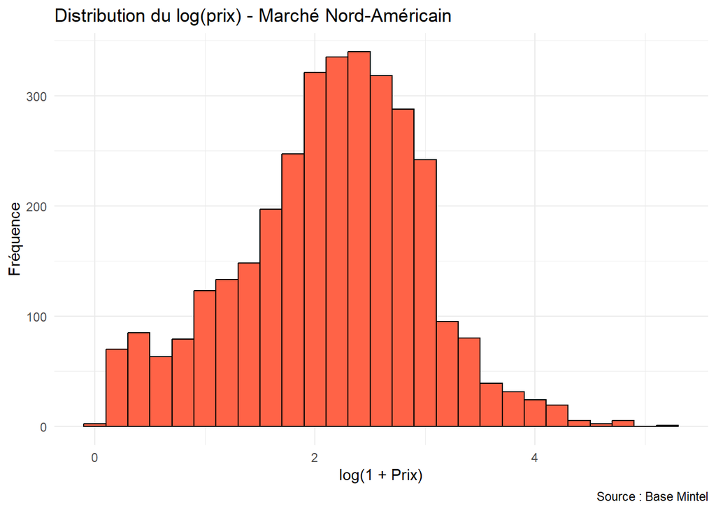

```r
ggplot(gnpd_north_american_market_tea, aes(x = log1p(`Price per 100 g/ml in Euros`))) +
  geom_histogram(binwidth = 0.2, fill = "tomato", color = "black") +
  labs(title = "Distribution du log(prix) - Marché Nord-Américain",
       x = "log(1 + Prix)", y = "Fréquence",
       caption = "Source : Base Mintel") +
  theme_minimal()
```

### Evolution du prix du thé sur le marché nord-américain au cours du temps

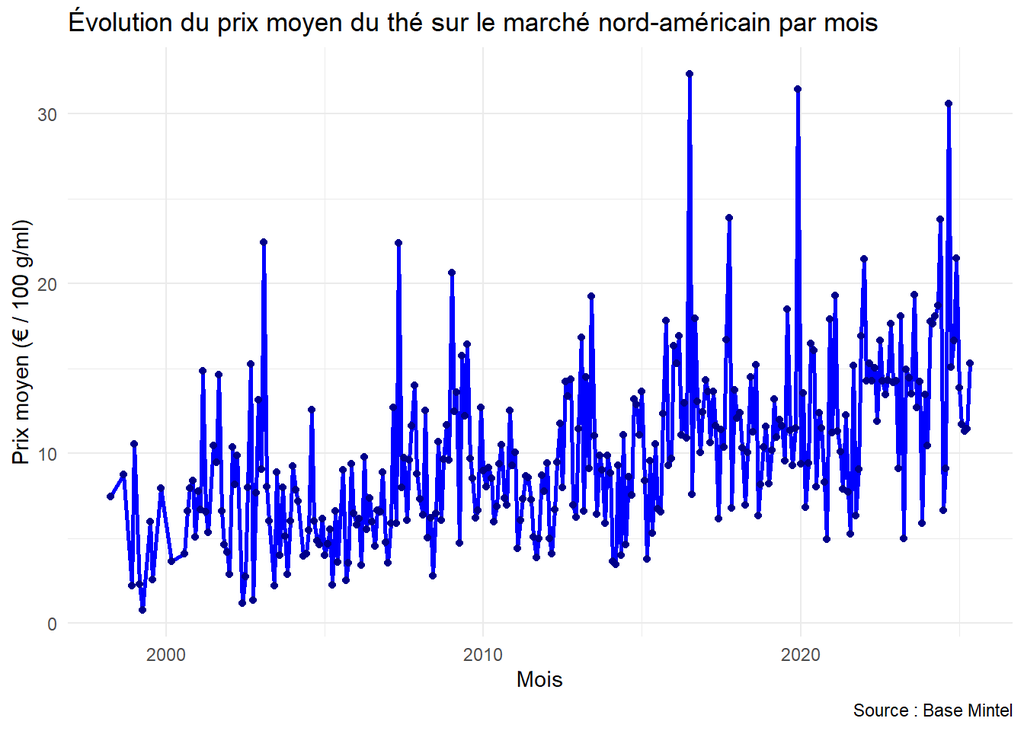

```r
library(lubridate)
library(dplyr)

# Créer une colonne "mois"
gnpd_north_american_market_tea <- gnpd_north_american_market_tea %>%
  mutate(Mois = floor_date(as.Date(`Date Published`), unit = "month"))

# Creation de la variable mois
prix_par_mois <- gnpd_north_american_market_tea %>%
  filter(!is.na(`Price per 100 g/ml in Euros`)) %>%
  group_by(Mois) %>%
  summarise(Prix_moyen = mean(`Price per 100 g/ml in Euros`))

# Calcul du prix moyen par mois
prix_par_mois <- gnpd_north_american_market_tea %>%
  filter(!is.na(`Price per 100 g/ml in Euros`)) %>%
  group_by(Mois) %>%
  summarise(Prix_moyen = mean(`Price per 100 g/ml in Euros`))

# Representation graphique
library(ggplot2)

ggplot(prix_par_mois, aes(x = Mois, y = Prix_moyen)) +
  geom_line(color = "blue", size = 1) +
  geom_point(color = "darkblue", size = 1.5) +
  labs(title = "Évolution du prix moyen du thé sur le marché nord-américain par mois",
       x = "Mois",
       y = "Prix moyen (€ / 100 g/ml)",
       caption = "Source : Base Mintel") +
  theme_minimal()
```

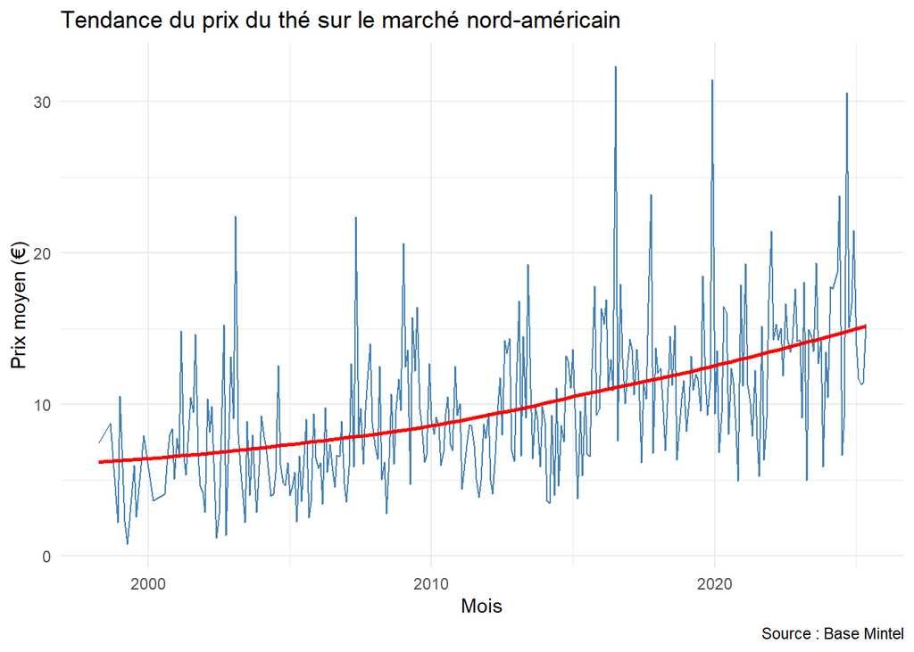

```r
# AUtre option
ggplot(prix_par_mois, aes(x = Mois, y = Prix_moyen)) +
  geom_line(color = "steelblue") +
  geom_smooth(method = "loess", color = "red", se = FALSE) +
  labs(title = "Tendance du prix du thé sur le marché nord-américain",
       x = "Mois", y = "Prix moyen (€)",
       caption = "Source : Base Mintel") +
  theme_minimal()
```

### par année

```r
# Calcul des prix moyens par année
```

```r
prix_par_annee <- gnpd_north_american_market_tea %>%
  mutate(annee = lubridate::year(`Date Published`)) %>%
  filter(!is.na(`Price per 100 g/ml in Euros`),
         !is.na(annee)) %>%
  group_by(annee) %>%
  summarise(
    n = n(),
    prix_moyen = mean(`Price per 100 g/ml in Euros`, na.rm = TRUE),
    prix_median = median(`Price per 100 g/ml in Euros`, na.rm = TRUE),
    prix_min = min(`Price per 100 g/ml in Euros`, na.rm = TRUE),
    prix_max = max(`Price per 100 g/ml in Euros`, na.rm = TRUE)
  ) %>%
  arrange(annee)
```

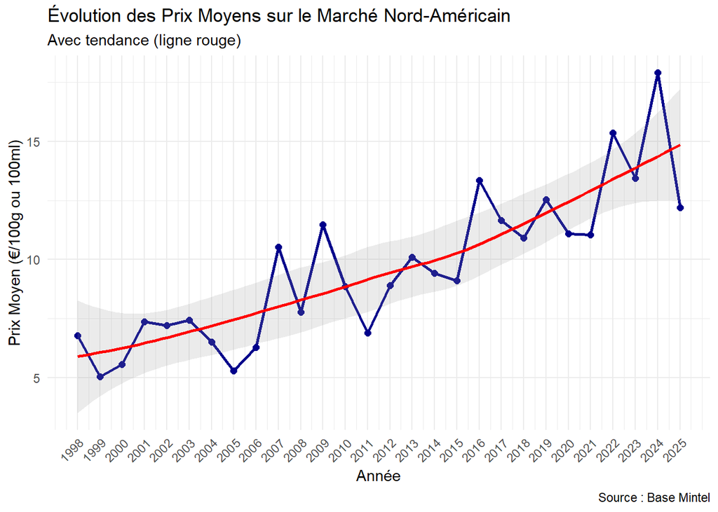

```r
# Graphique de l'évolution des prix moyens
ggplot(prix_par_annee, aes(x = annee, y = prix_moyen)) +
  geom_line(color = "darkblue", size = 1) +
  geom_point(color = "darkblue", size = 2) +
  geom_smooth(method = "loess", se = TRUE, color = "red", alpha = 0.2) +
  labs(
    title = "Évolution des Prix Moyens sur le Marché Nord-Américain",
    subtitle = "Avec tendance (ligne rouge)",
    x = "Année",
    y = "Prix Moyen (€/100g ou 100ml)",
    caption = "Source : Base Mintel"
  ) +
  theme_minimal() +
  scale_x_continuous(breaks = seq(min(prix_par_annee$annee), max(prix_par_annee$annee), by = 1)) +
  theme(axis.text.x = element_text(angle = 45, hjust = 1))
```

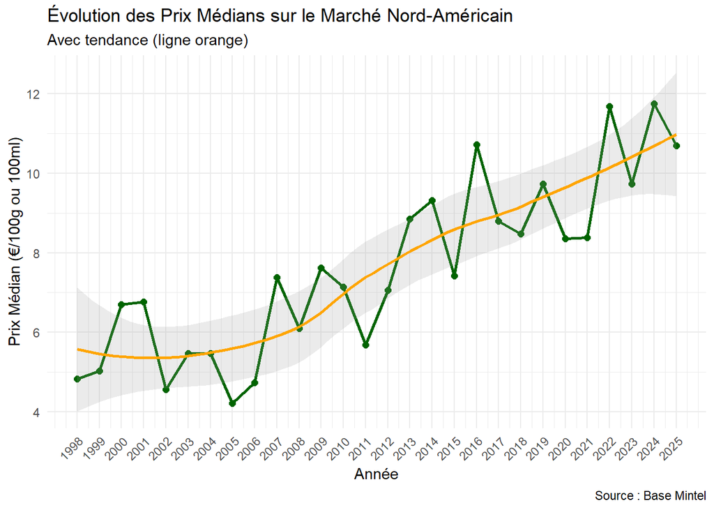

```r
##### prix median

ggplot(prix_par_annee, aes(x = annee, y = prix_median)) +
  geom_line(color = "darkgreen", size = 1) +
  geom_point(color = "darkgreen", size = 2) +
  geom_smooth(method = "loess", se = TRUE, color = "orange", alpha = 0.2) +
  labs(
    title = "Évolution des Prix Médians sur le Marché Nord-Américain",
    subtitle = "Avec tendance (ligne orange)",
    x = "Année",
    y = "Prix Médian (€/100g ou 100ml)",
    caption = "Source : Base Mintel"
  ) +
  theme_minimal() +
  scale_x_continuous(breaks = seq(min(prix_par_annee$annee), max(prix_par_annee$annee), by = 1)) +
  theme(axis.text.x = element_text(angle = 45, hjust = 1))
```

```r
# Affichage des statistiques annuelles
knitr::kable(prix_par_annee,
             caption = "Statistiques des Prix par Année - Marché Nord-Américain")
```

Statistiques des Prix par Année - Marché Nord-Américain

| annee | n | prix_moyen | prix_median | prix_min | prix_max |
| --- | --- | --- | --- | --- | --- |
| 1998 | 4 | 6.787500 | 4.825 | 0.46 | 17.04 |
| 1999 | 8 | 5.042500 | 5.025 | 0.49 | 10.56 |
| 2000 | 8 | 5.557500 | 6.700 | 0.11 | 8.41 |
| 2001 | 32 | 7.370625 | 6.770 | 0.45 | 18.58 |
| 2002 | 24 | 7.211250 | 4.555 | 0.33 | 16.80 |
| 2003 | 35 | 7.445143 | 5.470 | 0.11 | 42.84 |
| 2004 | 60 | 6.517333 | 5.465 | 0.53 | 33.92 |
| 2005 | 50 | 5.279800 | 4.215 | 0.07 | 24.27 |
| 2006 | 90 | 6.277556 | 4.730 | 0.24 | 37.78 |
| 2007 | 93 | 10.532258 | 7.380 | 0.41 | 119.03 |
| 2008 | 96 | 7.784167 | 6.095 | 0.20 | 51.95 |
| 2009 | 100 | 11.467200 | 7.625 | 0.33 | 89.35 |
| 2010 | 112 | 8.855625 | 7.135 | 0.39 | 62.90 |
| 2011 | 94 | 6.887234 | 5.680 | 0.41 | 31.20 |
| 2012 | 130 | 8.895923 | 7.055 | 0.20 | 61.83 |
| 2013 | 271 | 10.107823 | 8.850 | 0.17 | 42.19 |
| 2014 | 232 | 9.424957 | 9.320 | 0.24 | 56.30 |
| 2015 | 230 | 9.117565 | 7.415 | 0.13 | 85.84 |
| 2016 | 232 | 13.358966 | 10.720 | 0.22 | 163.50 |
| 2017 | 176 | 11.657784 | 8.800 | 0.29 | 62.25 |
| 2018 | 189 | 10.907619 | 8.470 | 0.28 | 70.02 |
| 2019 | 157 | 12.530446 | 9.730 | 0.48 | 113.67 |
| 2020 | 204 | 11.094216 | 8.350 | 0.24 | 72.23 |
| 2021 | 167 | 11.043174 | 8.380 | 0.24 | 68.13 |
| 2022 | 157 | 15.374140 | 11.680 | 0.29 | 83.83 |
| 2023 | 140 | 13.445429 | 9.730 | 0.61 | 55.20 |
| 2024 | 142 | 17.910211 | 11.740 | 0.48 | 90.48 |
| 2025 | 59 | 12.193390 | 10.690 | 0.51 | 40.30 |

# Analyse des type de produit lancés sur le marché nord-américain

```r
library(dplyr)
library(ggplot2)

# Comptage des types de lancement
launch_dist <- gnpd_north_american_market_tea %>%
  filter(!is.na(`Launch Type`)) %>%
  count(`Launch Type`, sort = TRUE)

print(launch_dist)
```

```
## # A tibble: 5 × 2
##   `Launch Type`                   n
##   <chr>                       <int>
## 1 New Variety/Range Extension  1483
## 2 New Product                   936
## 3 New Packaging                 722
## 4 Relaunch                      131
## 5 New Formulation                20
```

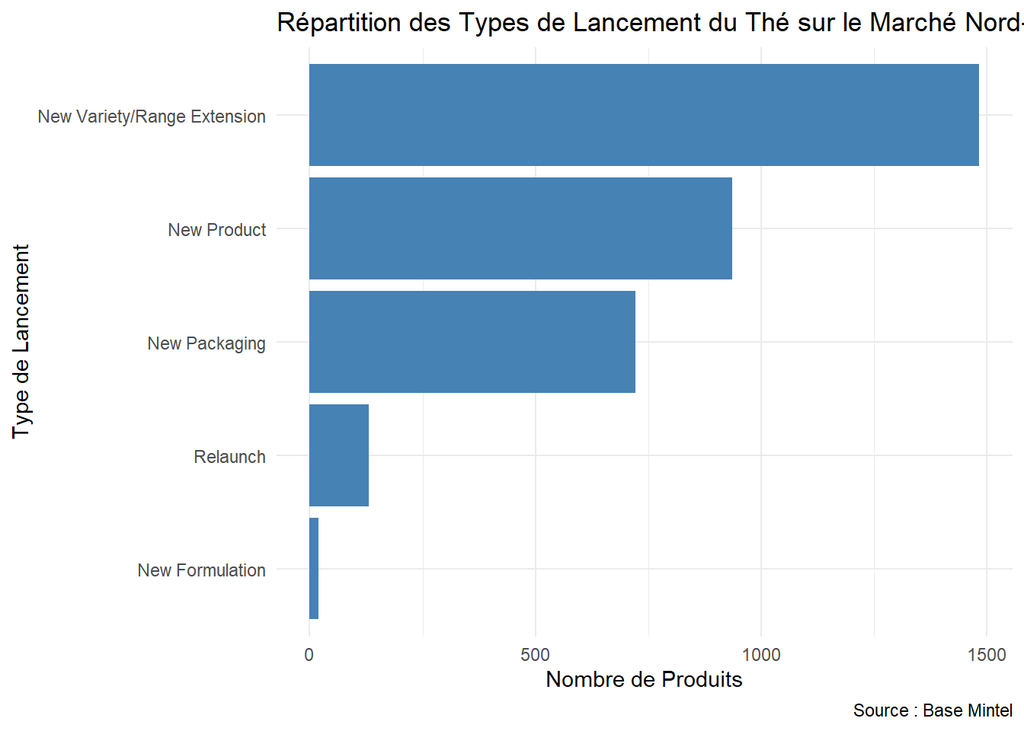

```r
ggplot(launch_dist, aes(x = reorder(`Launch Type`, n), y = n)) +
  geom_bar(stat = "identity", fill = "steelblue") +
  coord_flip() +
  labs(
    title = "Répartition des Types de Lancement du Thé sur le Marché Nord-Américain",
    x = "Type de Lancement",
    y = "Nombre de Produits",
    caption = "Source : Base Mintel"
  ) +
  theme_minimal()
```

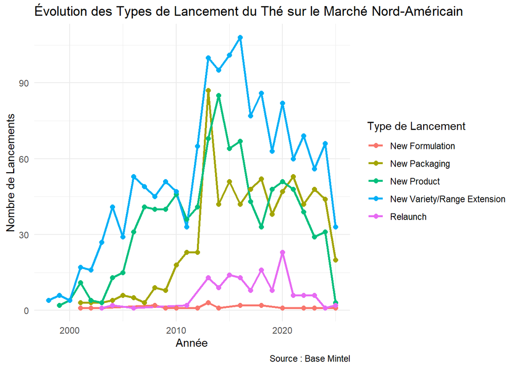

```r
launch_evolution <- gnpd_north_american_market_tea %>%
  mutate(annee = lubridate::year(`Date Published`)) %>%
  filter(!is.na(`Launch Type`)) %>%
  group_by(annee, `Launch Type`) %>%
  summarise(n = n()) %>%
  ungroup()

ggplot(launch_evolution, aes(x = annee, y = n, color = `Launch Type`)) +
  geom_line(size = 1) +
  geom_point(size = 2) +
  labs(
    title = "Évolution des Types de Lancement du Thé sur le Marché Nord-Américain",
    x = "Année",
    y = "Nombre de Lancements",
    color = "Type de Lancement",
    caption = "Source : Base Mintel"
  ) +
  theme_minimal()
```

## test statistiques

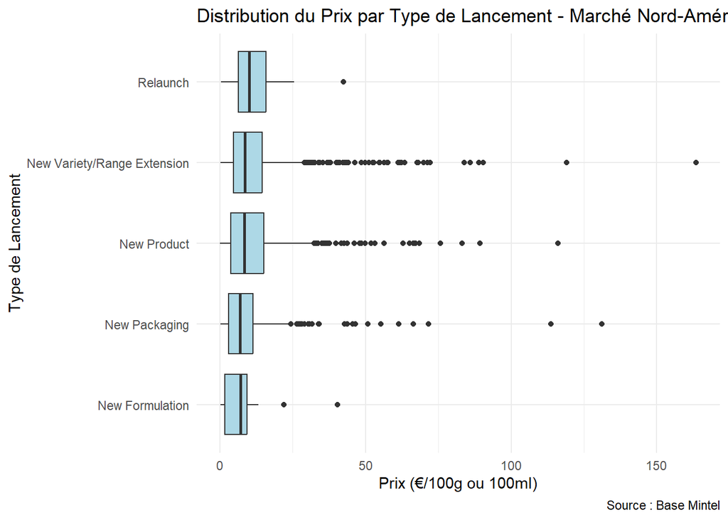

```r
library(ggplot2)

ggplot(gnpd_north_american_market_tea, aes(x = `Launch Type`, y = `Price per 100 g/ml in Euros`)) +
  geom_boxplot(fill = "lightblue") +
  coord_flip() +
  labs(
    title = "Distribution du Prix par Type de Lancement - Marché Nord-Américain",
    x = "Type de Lancement",
    y = "Prix (€/100g ou 100ml)",
    caption = "Source : Base Mintel"
  ) +
  theme_minimal()
```

```r
kruskal.test(`Price per 100 g/ml in Euros` ~ `Launch Type`, data = gnpd_north_american_market_tea)
```

```
##
##  Kruskal-Wallis rank sum test
##
## data:  Price per 100 g/ml in Euros by Launch Type
## Kruskal-Wallis chi-squared = 50.961, df = 4, p-value = 2.274e-10
```

# Interpretation

Le test de Kruskal-Wallis a été réalisé pour évaluer s’il existe une différence significative entre les prix du thé (€/100g ou 100ml) selon les différents types de lancement de produit (Launch Type) sur le marché nord-américain.

# Analyse de la variable private label

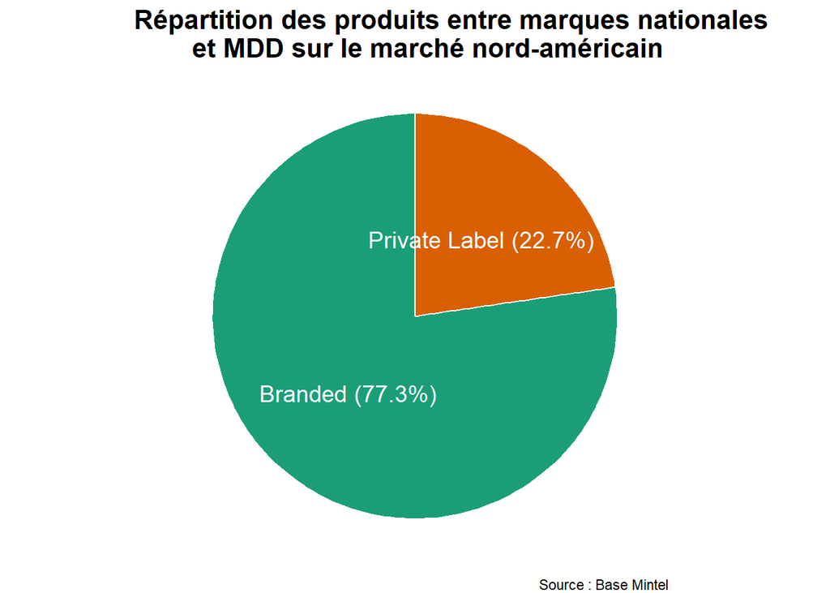

```r
library(ggplot2)
library(dplyr)

# Préparer les données
private_label_pie <- gnpd_north_american_market_tea %>%
  filter(!is.na(`Private Label`)) %>%
  count(`Private Label`) %>%
  mutate(
    pourcentage = round(100 * n / sum(n), 1),
    label = paste0(`Private Label`, " (", pourcentage, "%)")
  )

# Graphique en camembert
ggplot(private_label_pie, aes(x = "", y = n, fill = `Private Label`)) +
  geom_col(width = 1, color = "white") +
  coord_polar(theta = "y") +
  geom_text(aes(label = label), position = position_stack(vjust = 0.5), color = "white", size = 5) +
  scale_fill_manual(values = c("#1b9e77", "#d95f02")) +
  labs(
    title = "Répartition des produits entre marques nationales
    et MDD sur le marché nord-américain",
    fill = "Type de marque",
    caption = "Source : Base Mintel"
  ) +
  theme_void() +
  theme(
    plot.title = element_text(hjust = 0.2, size = 16, face = "bold"),
    legend.position = "none"
  )
```

```r
rm(private_label_pie)
```

# Resumé statistique

```r
gnpd_north_american_market_tea %>%
  filter(!is.na(`Private Label`), !is.na(`Price per 100 g/ml in Euros`)) %>%
  group_by(`Private Label`) %>%
  summarise(
    n = n(),
    prix_moyen = mean(`Price per 100 g/ml in Euros`, na.rm = TRUE),
    prix_median = median(`Price per 100 g/ml in Euros`, na.rm = TRUE),
    prix_min = min(`Price per 100 g/ml in Euros`, na.rm = TRUE),
    prix_max = max(`Price per 100 g/ml in Euros`, na.rm = TRUE)
  )
```

```
## # A tibble: 2 × 6
##   `Private Label`     n prix_moyen prix_median prix_min prix_max
##   <chr>           <int>      <dbl>       <dbl>    <dbl>    <dbl>
## 1 Branded          2536      11.7         8.86     0.07    164.
## 2 Private Label     745       7.90        5.45     0.17     62.2
```

[figure not shown]

```r
ggplot(gnpd_north_american_market_tea, aes(x = `Private Label`, y = `Price per 100 g/ml in Euros`, fill = `Private Label`)) +
  geom_boxplot() +
  scale_y_continuous(limits = c(0, quantile(gnpd_north_american_market_tea$`Price per 100 g/ml in Euros`, 0.95, na.rm = TRUE))) +
  labs(
    title = "Distribution des prix selon le type de marque - Marché Nord-Américain",
    x = "Type de marque",
    y = "Prix (€/100g ou 100ml)",
    caption = "Source : Base Mintel"
  ) +
  theme_minimal()
```

## test de wilcoxon

```r
wilcox.test(`Price per 100 g/ml in Euros` ~ `Private Label`, data = gnpd_north_american_market_tea)
```

```
##
##  Wilcoxon rank sum test with continuity correction
##
## data:  Price per 100 g/ml in Euros by Private Label
## W = 1191010, p-value < 2.2e-16
## alternative hypothesis: true location shift is not equal to 0
```

## Interpretation

Le test est hautement significatif (p < 0.001) → On rejette l’hypothèse nulle selon laquelle les deux groupes ont la même distribution des prix (en particulier, la même médiane).

Conclusion : Il existe une différence statistiquement significative entre les prix des produits “Branded” et “Private Label” sur le marché nord-américain.

## Construction de modele d’un premier modele

```r
lm_model <- lm(`Price per 100 g/ml in Euros` ~ `Private Label`, data = gnpd_north_american_market_tea)
summary(lm_model)
```

```
##
## Call:
## lm(formula = `Price per 100 g/ml in Euros` ~ `Private Label`,
##     data = gnpd_north_american_market_tea)
##
## Residuals:
##     Min      1Q  Median      3Q     Max
## -11.597  -6.317  -2.667   3.263 151.833
##
## Coefficients:
##                              Estimate Std. Error t value Pr(>|t|)
## (Intercept)                   11.6671     0.2244  52.002  < 2e-16 ***
## `Private Label`Private Label  -3.7642     0.4708  -7.995 1.78e-15 ***
## ---
## Signif. codes:  0 '***' 0.001 '**' 0.01 '*' 0.05 '.' 0.1 ' ' 1
##
## Residual standard error: 11.3 on 3279 degrees of freedom
##   (11 observations effacées parce que manquantes)
## Multiple R-squared:  0.01912,    Adjusted R-squared:  0.01882
## F-statistic: 63.92 on 1 and 3279 DF,  p-value: 1.783e-15
```

## analyse de la qualité du thé sur marché nord-américain

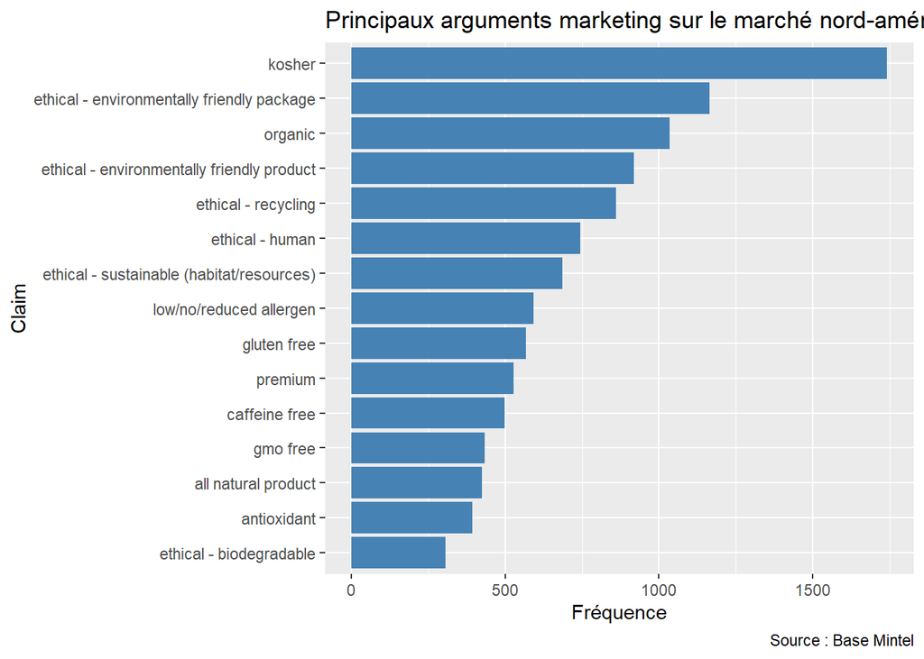

```r
# Extraction des claims individuels
claims <- gnpd_north_american_market_tea %>%
  filter(!is.na(`Positioning Claims`)) %>%
  unnest_tokens(claim, `Positioning Claims`, token = "regex",
                pattern = ",\\s*") %>%
  count(claim, sort = TRUE)

# Barplot des claims les plus fréquents
claims %>%
  slice_max(n, n = 15) %>%
  ggplot(aes(x = reorder(claim, n), y = n)) +
  geom_col(fill = "steelblue") +
  coord_flip() +
  labs(title = "Principaux arguments marketing sur le marché nord-américain",
       x = "Claim", y = "Fréquence",
       caption = "Source : Base Mintel")
```

```r
library(dplyr)
library(tidyr)

# Séparation des claims
claims_table <- gnpd_north_american_market_tea %>%
  separate_rows(`Positioning Claims`, sep = ",") %>%
  filter(!is.na(`Positioning Claims`)) %>%
  mutate(`Positioning Claims` = trimws(`Positioning Claims`)) %>%  # Nettoyage des espaces
  count(`Positioning Claims`, sort = TRUE)

# Top 15 + regroupement des autres
top_n <- 15

claims_table_top15 <- claims_table %>%
  mutate(`Positioning Claims` = ifelse(row_number() <= top_n, `Positioning Claims`, "Autres")) %>%
  group_by(`Positioning Claims`) %>%
  summarise(Frequence = sum(n), .groups = "drop") %>%
  arrange(desc(Frequence)) %>%
  mutate(Part = round(Frequence / sum(Frequence) * 100, 2))

# Affichage du tableau final
claims_table_top15
```

```
## # A tibble: 16 × 3
##    `Positioning Claims`                       Frequence  Part
##    <chr>                                          <int> <dbl>
##  1 Autres                                          3813 25.9
##  2 Kosher                                          1742 11.8
##  3 Ethical - Environmentally Friendly Package      1165  7.92
##  4 Organic                                         1036  7.05
##  5 Ethical - Environmentally Friendly Product       918  6.24
##  6 Ethical - Recycling                              861  5.86
##  7 Ethical - Human                                  743  5.05
##  8 Ethical - Sustainable (Habitat/Resources)        686  4.67
##  9 Low/No/Reduced Allergen                          592  4.03
## 10 Gluten Free                                      568  3.86
## 11 Premium                                          526  3.58
## 12 Caffeine Free                                    499  3.39
## 13 GMO Free                                         434  2.95
## 14 All Natural Product                              424  2.88
## 15 Antioxidant                                      392  2.67
## 16 Ethical - Biodegradable                          306  2.08
```

Les claims marketing ont été regroupés en six catégories, selon les typologies proposées par Grunert (2005), Verbeke (2008), Aschemann-Witzel et al. (2013), et Kihlberg & Risvik (2007), qui distinguent les dimensions nutritionnelles, fonctionnelles, environnementales, sensorielles, pratiques, et socio-démographiques des allégations de produits alimentaires.

```r
library(dplyr)
library(stringr)

# Définir les mots-clés pour chaque catégorie
claims_sante <- c("antioxidant", "functional - digestive", "functional - energy", "functional - slimming",
                  "functional - other", "functional - stress & sleep", "functional - immune system",
                  "functional - beauty benefits", "functional - brain & nervous system",
                  "functional - cardiovascular", "functional - bone health", "functional - skin",
                  "high satiety", "anti-ageing", "nails & hair", "vitamin/mineral fortified")

claims_nutrition <- c("caffeine free", "no additives/preservatives", "free from added/artificial flavourings",
                      "free from added/artificial additives", "free from added/artificial preservatives",
                      "free from added/artificial colourings", "low/no/reduced allergen", "low/no/reduced calorie",
                      "vegetarian", "vegan/no animal ingredients", "kosher", "gmo free", "sugar free",
                      "no added sugar", "diabetic", "low/no/reduced fat", "low/no/reduced sodium",
                      "low/no/reduced lactose", "wholegrain")

claims_ethique <- c("organic", "ethical - environmentally friendly package", "ethical - recycling",
                    "ethical - environmentally friendly product", "ethical - human",
                    "ethical - sustainable (habitat/resources)", "ethical - toxins free",
                    "ethical - biodegradable", "ethical - charity", "carbon neutral", "ethical - animal")

claims_packaging <- c("convenient packaging", "time/speed", "ease of use", "interesting packaging",
                      "microwaveable", "refill/refillable", "portionability", "on-the-go")

claims_marketing <- c("premium", "social media", "seasonal", "limited edition", "event merchandising",
                      "novel", "cobranded", "economy")

claims_ciblage <- c("maternal", "children (5-12)", "female", "male", "plant based")

# Fonction pour détecter la présence d'un mot-clé
detect_claim <- function(text, keywords) {
  if (is.na(text)) return("non")
  any(str_detect(text, fixed(keywords, ignore_case = TRUE))) %>% ifelse("oui", "non")
}

# Créer les colonnes
gnpd_north_american_market_tea <- gnpd_north_american_market_tea %>%
  mutate(claim_sante = map_chr(`Positioning Claims`, ~ detect_claim(.x, claims_sante)))
gnpd_north_american_market_tea <- gnpd_north_american_market_tea %>%
  mutate(
    claim_nutrition = map_chr(`Positioning Claims`, ~ detect_claim(.x, claims_nutrition)))
gnpd_north_american_market_tea <- gnpd_north_american_market_tea %>%
  mutate(
    claim_ethique = map_chr(`Positioning Claims`, ~ detect_claim(.x, claims_ethique)))
gnpd_north_american_market_tea <- gnpd_north_american_market_tea %>%
  mutate(
    claim_packaging = map_chr(`Positioning Claims`, ~ detect_claim(.x, claims_packaging)))
gnpd_north_american_market_tea <- gnpd_north_american_market_tea %>%
  mutate(
    claim_marketing = map_chr(`Positioning Claims`, ~ detect_claim(.x, claims_marketing)))
gnpd_north_american_market_tea <- gnpd_north_american_market_tea %>%
  mutate(
    claim_ciblage = map_chr(`Positioning Claims`, ~ detect_claim(.x, claims_ciblage)))
```

## Creation de la variable score qualité en fonction de l’argument marketing

```r
gnpd_north_american_market_tea <- gnpd_north_american_market_tea %>%
  mutate(
    score_qualite =
      5 * (claim_sante == "oui") +
      4 * (claim_nutrition == "oui") +
      5 * (claim_ethique == "oui") +
      1.5 * (claim_packaging == "oui") +
      2.5 * (claim_marketing == "oui") +
      0.5 * (claim_ciblage == "oui")
  )

gnpd_north_american_market_tea <- gnpd_north_american_market_tea %>%
  mutate(
    niveau_qualite = case_when(
      score_qualite <= 4 ~ "faible",
      score_qualite <= 11 ~ "moyenne",
      score_qualite > 11 ~ "élevée"
    )
  )
```

# Analyse score vs prix

```r
gnpd_north_american_market_tea %>%
  filter(!is.na(niveau_qualite), !is.na(`Price per 100 g/ml in Euros`)) %>%
  group_by(niveau_qualite) %>%
  summarise(
    n = n(),
    prix_moyen = mean(`Price per 100 g/ml in Euros`, na.rm = TRUE),
    prix_median = median(`Price per 100 g/ml in Euros`, na.rm = TRUE),
    prix_min = min(`Price per 100 g/ml in Euros`, na.rm = TRUE),
    prix_max = max(`Price per 100 g/ml in Euros`, na.rm = TRUE)
  ) %>%
  arrange(prix_moyen)
```

```
## # A tibble: 3 × 6
##   niveau_qualite     n prix_moyen prix_median prix_min prix_max
##   <chr>          <int>      <dbl>       <dbl>    <dbl>    <dbl>
## 1 faible           831       8.60        5.9      0.1      116.
## 2 moyenne         1574      10.9         7.97     0.07     164.
## 3 élevée           887      12.6        10.4      0.29     119.
```

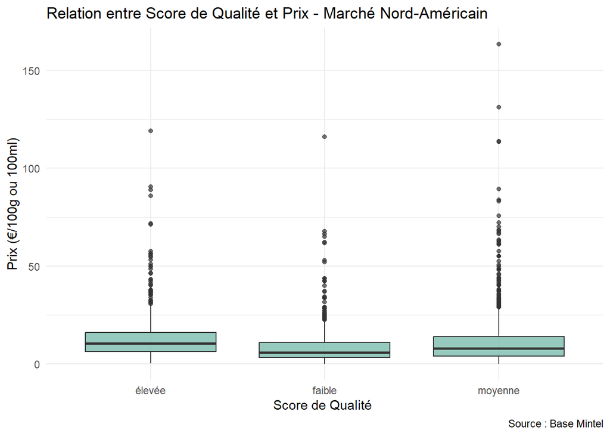

```r
ggplot(gnpd_north_american_market_tea, aes(x = factor(niveau_qualite), y = `Price per 100 g/ml in Euros`)) +
  geom_boxplot(fill = "#69b3a2", alpha = 0.7) +
  #geom_jitter(width = 0.2, alpha = 0.3, color = "grey30") +
  labs(
    title = "Relation entre Score de Qualité et Prix - Marché Nord-Américain",
    x = "Score de Qualité ",
    y = "Prix (€/100g ou 100ml)",
    caption = "Source : Base Mintel"
  ) +
  theme_minimal()
```

```r
modele_score <- lm(`Price per 100 g/ml in Euros` ~ niveau_qualite, data = gnpd_north_american_market_tea)
summary(modele_score)
```

```
##
## Call:
## lm(formula = `Price per 100 g/ml in Euros` ~ niveau_qualite,
##     data = gnpd_north_american_market_tea)
##
## Residuals:
##     Min      1Q  Median      3Q     Max
## -12.342  -6.253  -2.670   2.971 152.578
##
## Coefficients:
##                       Estimate Std. Error t value Pr(>|t|)
## (Intercept)            12.6317     0.3795  33.282  < 2e-16 ***
## niveau_qualitefaible   -4.0342     0.5457  -7.393 1.82e-13 ***
## niveau_qualitemoyenne  -1.7101     0.4746  -3.603 0.000319 ***
## ---
## Signif. codes:  0 '***' 0.001 '**' 0.01 '*' 0.05 '.' 0.1 ' ' 1
##
## Residual standard error: 11.3 on 3289 degrees of freedom
## Multiple R-squared:  0.01645,    Adjusted R-squared:  0.01586
## F-statistic: 27.51 on 2 and 3289 DF,  p-value: 1.414e-12
```